# Heart Disease — Exploratory Data Analysis

**Dataset:** UCI Heart Disease (Cleveland processed)

Sections:

1. Loading dataset and basic inspection
2. Identifying missing values
3. Checking target / class balance / imbalance
4. Feature distributions (histograms / count plots)
5. Outlier inspection (boxplots by target)
6. Feature Correlation heatmap
7. Save processed CSV + EDA artifacts

```python
import sys
from pathlib import Path

# Make src/ importable when running from notebooks/
ROOT = Path.cwd().parent if Path.cwd().name == 'notebooks' else Path.cwd()
sys.path.insert(0, str(ROOT))

import numpy as np
import pandas as pd
import matplotlib.pyplot as plt
import seaborn as sns

from src.data_loader import (
    load_raw, clean, save_processed, summary,
    NUMERIC_FEATURES, CATEGORICAL_FEATURES, TARGET,
)

sns.set_theme(style='whitegrid', context='notebook')
ARTIFACTS = ROOT / 'reports' / 'figures'
ARTIFACTS.mkdir(parents=True, exist_ok=True)
print('Artifacts ->', ARTIFACTS)
```

```
Artifacts -> C:\Users\vinogane\OneDrive - Cisco\Desktop\BITS-MTech\Semester-2\MLOps\Assignment1\reports\figures
```

## 1. Loading Dataset and Basic Inspection

```python
raw = load_raw()
print('Data Input shape:', raw.shape)
raw.head()
```

```
Data Input shape: (303, 14)
```

|  | age | sex | cp | trestbps | chol | fbs | restecg | thalach | exang | oldpeak | slope | ca | thal | num |
| --- | --- | --- | --- | --- | --- | --- | --- | --- | --- | --- | --- | --- | --- | --- |
| 0 | 63.0 | 1.0 | 1.0 | 145.0 | 233.0 | 1.0 | 2.0 | 150.0 | 0.0 | 2.3 | 3.0 | 0.0 | 6.0 | 0 |
| 1 | 67.0 | 1.0 | 4.0 | 160.0 | 286.0 | 0.0 | 2.0 | 108.0 | 1.0 | 1.5 | 2.0 | 3.0 | 3.0 | 2 |
| 2 | 67.0 | 1.0 | 4.0 | 120.0 | 229.0 | 0.0 | 2.0 | 129.0 | 1.0 | 2.6 | 2.0 | 2.0 | 7.0 | 1 |
| 3 | 37.0 | 1.0 | 3.0 | 130.0 | 250.0 | 0.0 | 0.0 | 187.0 | 0.0 | 3.5 | 3.0 | 0.0 | 3.0 | 0 |
| 4 | 41.0 | 0.0 | 2.0 | 130.0 | 204.0 | 0.0 | 2.0 | 172.0 | 0.0 | 1.4 | 1.0 | 0.0 | 3.0 | 0 |

```python
df = clean(raw)
print('Cleaned Data shape:', df.shape)
print('\nSummary:', summary(df))
df.describe().T
```

```
Cleaned Data shape: (303, 14)

Summary: {'n_rows': 303, 'n_cols': 14, 'n_missing': 6, 'class_balance': {0: 0.5412541254125413, 1: 0.45874587458745875}}
```

|  | count | mean | std | min | 25% | 50% | 75% | max |
| --- | --- | --- | --- | --- | --- | --- | --- | --- |
| age | 303.0 | 54.438944 | 9.038662 | 29.0 | 48.0 | 56.0 | 61.0 | 77.0 |
| sex | 303.0 | 0.679868 | 0.467299 | 0.0 | 0.0 | 1.0 | 1.0 | 1.0 |
| cp | 303.0 | 3.158416 | 0.960126 | 1.0 | 3.0 | 3.0 | 4.0 | 4.0 |
| trestbps | 303.0 | 131.689769 | 17.599748 | 94.0 | 120.0 | 130.0 | 140.0 | 200.0 |
| chol | 303.0 | 246.693069 | 51.776918 | 126.0 | 211.0 | 241.0 | 275.0 | 564.0 |
| fbs | 303.0 | 0.148515 | 0.356198 | 0.0 | 0.0 | 0.0 | 0.0 | 1.0 |
| restecg | 303.0 | 0.990099 | 0.994971 | 0.0 | 0.0 | 1.0 | 2.0 | 2.0 |
| thalach | 303.0 | 149.607261 | 22.875003 | 71.0 | 133.5 | 153.0 | 166.0 | 202.0 |
| exang | 303.0 | 0.326733 | 0.469794 | 0.0 | 0.0 | 0.0 | 1.0 | 1.0 |
| oldpeak | 303.0 | 1.039604 | 1.161075 | 0.0 | 0.0 | 0.8 | 1.6 | 6.2 |
| slope | 303.0 | 1.600660 | 0.616226 | 1.0 | 1.0 | 2.0 | 2.0 | 3.0 |
| ca | 299.0 | 0.672241 | 0.937438 | 0.0 | 0.0 | 0.0 | 1.0 | 3.0 |
| thal | 301.0 | 4.734219 | 1.939706 | 3.0 | 3.0 | 3.0 | 7.0 | 7.0 |
| target | 303.0 | 0.458746 | 0.499120 | 0.0 | 0.0 | 0.0 | 1.0 | 1.0 |

## 2. Identifying Missing values

```python
missing = raw.isna().sum().sort_values(ascending=False)
missing = missing[missing > 0]
print('Columns with missing values:')
print(missing)
print('\nTotal missing cells:', int(raw.isna().sum().sum()))
print('% rows with any missing:', round(raw.isna().any(axis=1).mean()*100, 2), '%')
```

```
Columns with missing values:
ca      4
thal    2
dtype: int64

Total missing cells: 6
% rows with any missing: 1.98 %
```

## 3. Checking Target / Class balance / Imbalance

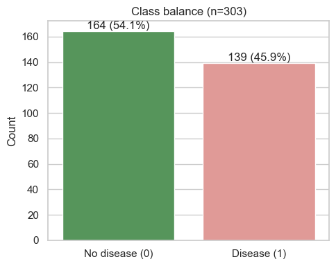

```python
fig, ax = plt.subplots(figsize=(5, 4))
counts = df[TARGET].value_counts().sort_index()
sns.barplot(x=counts.index, y=counts.values, ax=ax,
            palette=["#4C9F52", "#EC8F8B"])
ax.set_xticklabels(['No disease (0)', 'Disease (1)'])
ax.set_ylabel('Count'); ax.set_xlabel('')
ax.set_title(f'Class balance (n={len(df)})')
for i, v in enumerate(counts.values):
    ax.text(i, v+2, f'{v} ({v/len(df)*100:.1f}%)', ha='center')
plt.tight_layout(); plt.savefig(ARTIFACTS/'class_balance.png', dpi=120); plt.show()
```

## 4. Feature distributions

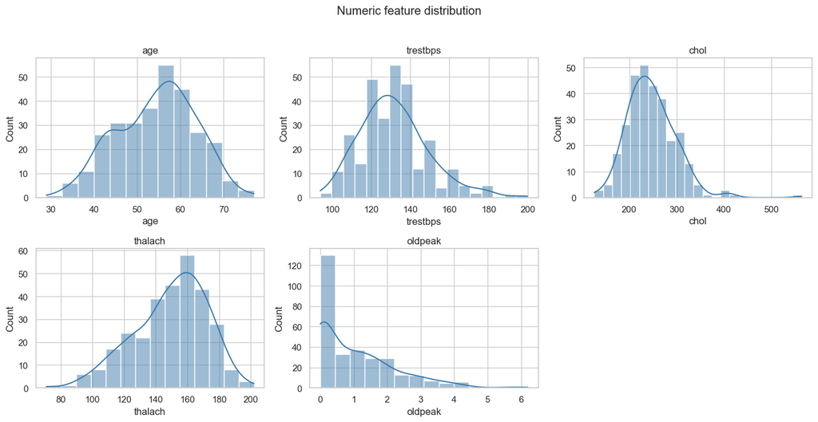

```python
fig, axes = plt.subplots(2, 3, figsize=(14, 7))
for ax, col in zip(axes.flat, NUMERIC_FEATURES + ['']):
    if col == '':
        ax.axis('off'); continue
    sns.histplot(df[col].dropna(), kde=True, ax=ax, color='#3F7CAC')
    ax.set_title(col)
plt.suptitle('Numeric feature distribution', y=1.02)
plt.tight_layout(); plt.savefig(ARTIFACTS/'numeric_hist.png', dpi=120); plt.show()
```

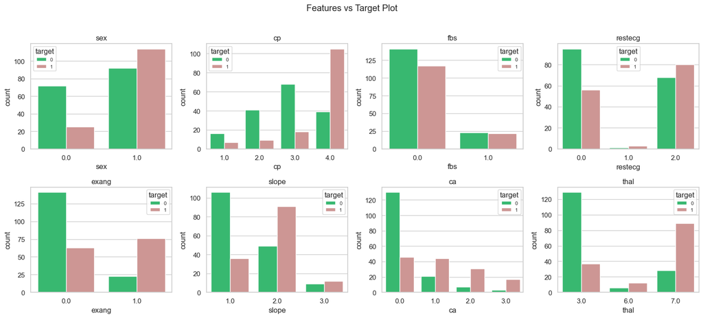

```python
fig, axes = plt.subplots(2, 4, figsize=(16, 7))
for ax, col in zip(axes.flat, CATEGORICAL_FEATURES):
    sns.countplot(data=df, x=col, hue=TARGET, ax=ax,
                  palette=["#23CD6D", "#D78D8A"])
    ax.set_title(col); ax.legend(title='target', fontsize=8)
plt.suptitle('Features vs Target Plot', y=1.02)
plt.tight_layout(); plt.savefig(ARTIFACTS/'categorical_vs_target.png', dpi=120); plt.show()
```

## 5. Outlier inspection — boxplots of numeric features by target

Box plots show the median, IQR (25-75th percentile), whiskers (1.5 × IQR) and individual points beyond the whiskers — i.e. **outliers**. Splitting by `target` also reveals whether the distribution shifts between the two classes.

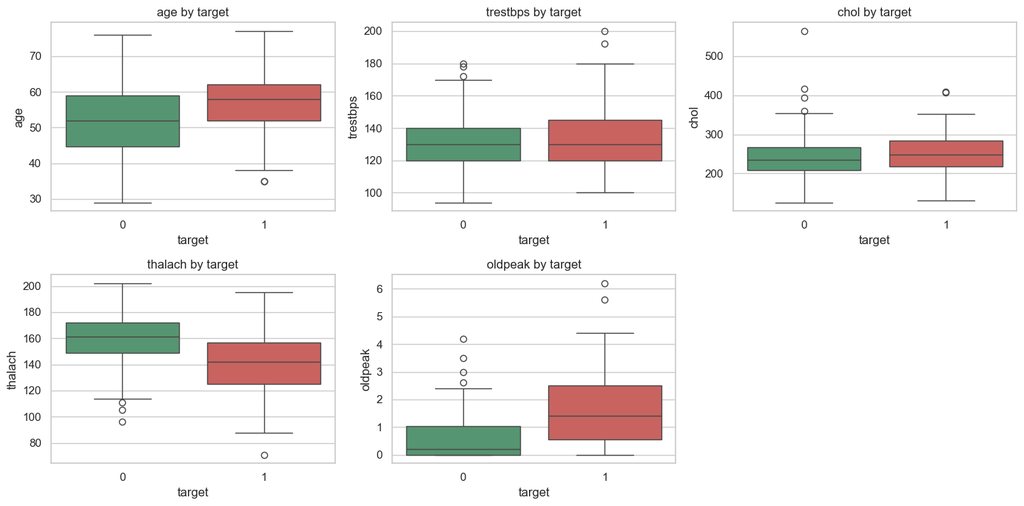

```python
fig, axes = plt.subplots(2, 3, figsize=(14, 7))
for ax, col in zip(axes.flat, NUMERIC_FEATURES + ['']):
    if col == '':
        ax.axis('off'); continue
    sns.boxplot(data=df, x=TARGET, y=col, ax=ax,
                palette=['#4C9F70', '#D9534F'])
    ax.set_title(f'{col} by target')
plt.tight_layout(); plt.savefig(ARTIFACTS/'numeric_vs_target.png', dpi=120); plt.show()
```

## 6. Feature Correlation heatmap

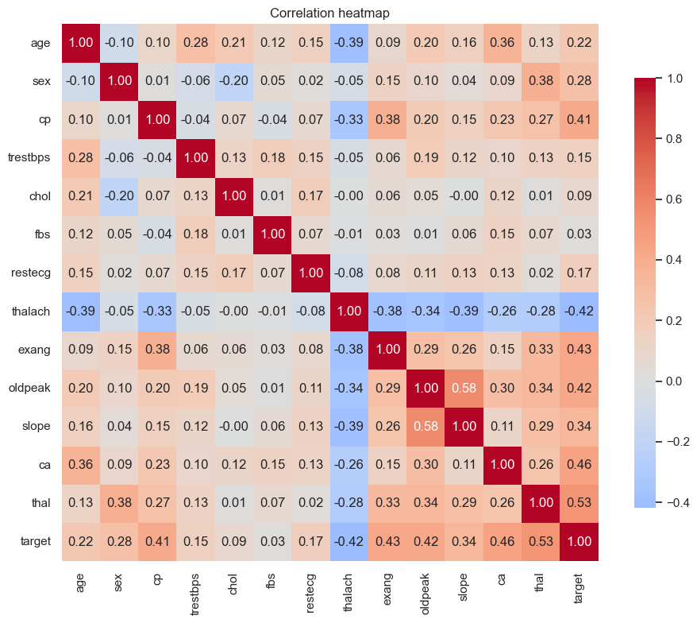

```
Top correlations with target:
thal       0.525689
ca         0.460442
exang      0.431894
oldpeak    0.424510
thalach    0.417167
cp         0.414446
slope      0.339213
sex        0.276816
Name: target, dtype: float64
```

```python
fig, ax = plt.subplots(figsize=(10, 8))
corr = df.corr(numeric_only=True)
sns.heatmap(corr, annot=True, fmt='.2f', cmap='coolwarm',
            center=0, ax=ax, square=True, cbar_kws={'shrink': 0.8})
ax.set_title('Correlation heatmap')
plt.tight_layout(); plt.savefig(ARTIFACTS/'correlation_heatmap.png', dpi=120); plt.show()

print('\nTop correlations with target:')
print(corr[TARGET].drop(TARGET).abs().sort_values(ascending=False).head(8))
```

## 7. Save processed CSV

```python
out = save_processed(df)
print('Processed dataset ->', out)
print('Figures ->', ARTIFACTS)
```

```
Processed dataset -> C:\Users\vinogane\OneDrive - Cisco\Desktop\BITS-MTech\Semester-2\MLOps\Assignment1\data\processed\heart_cleveland.csv
Figures -> C:\Users\vinogane\OneDrive - Cisco\Desktop\BITS-MTech\Semester-2\MLOps\Assignment1\reports\figures
```

## Key findings

- **Size:** 303 rows × 14 columns; nearly balanced classes (≈54% / 46%).
- **Missing values:** Only 6 missing cells across `ca` and `thal` — handled by median/mode imputation in the preprocessing pipeline.
- **Strongest associations** with the target are typically `cp` (chest pain type), `thalach` (max heart rate), `oldpeak`, `exang`, `ca`, and `thal`.
- **Scales differ widely** (`age` ~30-80 vs `oldpeak` ~0-6) → standard scaling required for distance-based / linear models.
- **Categorical variables** are integer-encoded but nominal (`cp`, `restecg`, `slope`, `thal`) → one-hot encode in the pipeline.